# Risk Factor Analysis

## Outcome Variable

**Outcome Variable:** sstunted

## Predictor Variables

**Intervention Variable:** earlybf

**Adjustment Set:**

unadjusted

## Stratifying Variables

The analysis was stratified on these variable(s):

- agecat
- studyid
- country

## Data Summary

| agecat | studyid | country | earlybf | sstunted | n_cell | n | outcome_variable |
| --- | --- | --- | --- | --- | --- | --- | --- |
| Birth | ki0047075b-MAL-ED | BANGLADESH | 1 | 0 | 145 | 230 | sstunted |
| Birth | ki0047075b-MAL-ED | BANGLADESH | 1 | 1 | 2 | 230 | sstunted |
| Birth | ki0047075b-MAL-ED | BANGLADESH | 0 | 0 | 76 | 230 | sstunted |
| Birth | ki0047075b-MAL-ED | BANGLADESH | 0 | 1 | 7 | 230 | sstunted |
| Birth | ki0047075b-MAL-ED | BRAZIL | 1 | 0 | 26 | 65 | sstunted |
| Birth | ki0047075b-MAL-ED | BRAZIL | 1 | 1 | 2 | 65 | sstunted |
| Birth | ki0047075b-MAL-ED | BRAZIL | 0 | 0 | 36 | 65 | sstunted |
| Birth | ki0047075b-MAL-ED | BRAZIL | 0 | 1 | 1 | 65 | sstunted |
| Birth | ki0047075b-MAL-ED | INDIA | 1 | 0 | 31 | 46 | sstunted |
| Birth | ki0047075b-MAL-ED | INDIA | 1 | 1 | 1 | 46 | sstunted |
| Birth | ki0047075b-MAL-ED | INDIA | 0 | 0 | 13 | 46 | sstunted |
| Birth | ki0047075b-MAL-ED | INDIA | 0 | 1 | 1 | 46 | sstunted |
| Birth | ki0047075b-MAL-ED | NEPAL | 1 | 0 | 14 | 27 | sstunted |
| Birth | ki0047075b-MAL-ED | NEPAL | 1 | 1 | 0 | 27 | sstunted |
| Birth | ki0047075b-MAL-ED | NEPAL | 0 | 0 | 12 | 27 | sstunted |
| Birth | ki0047075b-MAL-ED | NEPAL | 0 | 1 | 1 | 27 | sstunted |
| Birth | ki0047075b-MAL-ED | PERU | 1 | 0 | 173 | 233 | sstunted |
| Birth | ki0047075b-MAL-ED | PERU | 1 | 1 | 2 | 233 | sstunted |
| Birth | ki0047075b-MAL-ED | PERU | 0 | 0 | 56 | 233 | sstunted |
| Birth | ki0047075b-MAL-ED | PERU | 0 | 1 | 2 | 233 | sstunted |
| Birth | ki0047075b-MAL-ED | SOUTH AFRICA | 1 | 0 | 69 | 111 | sstunted |
| Birth | ki0047075b-MAL-ED | SOUTH AFRICA | 1 | 1 | 0 | 111 | sstunted |
| Birth | ki0047075b-MAL-ED | SOUTH AFRICA | 0 | 0 | 41 | 111 | sstunted |
| Birth | ki0047075b-MAL-ED | SOUTH AFRICA | 0 | 1 | 1 | 111 | sstunted |
| Birth | ki0047075b-MAL-ED | TANZANIA, UNITED REPUBLIC OF | 1 | 0 | 103 | 125 | sstunted |
| Birth | ki0047075b-MAL-ED | TANZANIA, UNITED REPUBLIC OF | 1 | 1 | 8 | 125 | sstunted |
| Birth | ki0047075b-MAL-ED | TANZANIA, UNITED REPUBLIC OF | 0 | 0 | 12 | 125 | sstunted |
| Birth | ki0047075b-MAL-ED | TANZANIA, UNITED REPUBLIC OF | 0 | 1 | 2 | 125 | sstunted |
| Birth | ki1000109-EE | PAKISTAN | 1 | 0 | 38 | 229 | sstunted |
| Birth | ki1000109-EE | PAKISTAN | 1 | 1 | 6 | 229 | sstunted |

[output cut: 134 more lines]

The following strata were considered:

- agecat: 24 months, studyid: ki0047075b-MAL-ED, country: BANGLADESH
- agecat: 24 months, studyid: ki0047075b-MAL-ED, country: BRAZIL
- agecat: 24 months, studyid: ki0047075b-MAL-ED, country: INDIA
- agecat: 24 months, studyid: ki0047075b-MAL-ED, country: NEPAL
- agecat: 24 months, studyid: ki0047075b-MAL-ED, country: PERU
- agecat: 24 months, studyid: ki0047075b-MAL-ED, country: SOUTH AFRICA
- agecat: 24 months, studyid: ki0047075b-MAL-ED, country: TANZANIA, UNITED REPUBLIC OF
- agecat: 24 months, studyid: ki1000109-EE, country: PAKISTAN
- agecat: 24 months, studyid: ki1017093c-NIH-Crypto, country: BANGLADESH
- agecat: 24 months, studyid: ki1113344-GMS-Nepal, country: NEPAL
- agecat: 24 months, studyid: ki1126311-ZVITAMBO, country: ZIMBABWE
- agecat: 24 months, studyid: kiGH5241-JiVitA-3, country: BANGLADESH
- agecat: 24 months, studyid: kiGH5241-JiVitA-4, country: BANGLADESH
- agecat: 6 months, studyid: ki0047075b-MAL-ED, country: BANGLADESH
- agecat: 6 months, studyid: ki0047075b-MAL-ED, country: BRAZIL
- agecat: 6 months, studyid: ki0047075b-MAL-ED, country: INDIA
- agecat: 6 months, studyid: ki0047075b-MAL-ED, country: NEPAL
- agecat: 6 months, studyid: ki0047075b-MAL-ED, country: PERU
- agecat: 6 months, studyid: ki0047075b-MAL-ED, country: SOUTH AFRICA
- agecat: 6 months, studyid: ki0047075b-MAL-ED, country: TANZANIA, UNITED REPUBLIC OF
- agecat: 6 months, studyid: ki1000109-EE, country: PAKISTAN
- agecat: 6 months, studyid: ki1000304b-SAS-CompFeed, country: INDIA
- agecat: 6 months, studyid: ki1017093c-NIH-Crypto, country: BANGLADESH
- agecat: 6 months, studyid: ki1113344-GMS-Nepal, country: NEPAL
- agecat: 6 months, studyid: ki1126311-ZVITAMBO, country: ZIMBABWE
- agecat: 6 months, studyid: kiGH5241-JiVitA-3, country: BANGLADESH
- agecat: 6 months, studyid: kiGH5241-JiVitA-4, country: BANGLADESH
- agecat: Birth, studyid: ki0047075b-MAL-ED, country: BANGLADESH
- agecat: Birth, studyid: ki0047075b-MAL-ED, country: BRAZIL
- agecat: Birth, studyid: ki0047075b-MAL-ED, country: INDIA
- agecat: Birth, studyid: ki0047075b-MAL-ED, country: NEPAL
- agecat: Birth, studyid: ki0047075b-MAL-ED, country: PERU
- agecat: Birth, studyid: ki0047075b-MAL-ED, country: SOUTH AFRICA
- agecat: Birth, studyid: ki0047075b-MAL-ED, country: TANZANIA, UNITED REPUBLIC OF
- agecat: Birth, studyid: ki1000109-EE, country: PAKISTAN
- agecat: Birth, studyid: ki1000304b-SAS-CompFeed, country: INDIA
- agecat: Birth, studyid: ki1017093c-NIH-Crypto, country: BANGLADESH
- agecat: Birth, studyid: ki1113344-GMS-Nepal, country: NEPAL
- agecat: Birth, studyid: ki1126311-ZVITAMBO, country: ZIMBABWE
- agecat: Birth, studyid: kiGH5241-JiVitA-3, country: BANGLADESH
- agecat: Birth, studyid: kiGH5241-JiVitA-4, country: BANGLADESH

### Dropped Strata

Some strata were dropped due to rare outcomes:

- agecat: Birth, studyid: ki0047075b-MAL-ED, country: BANGLADESH
- agecat: Birth, studyid: ki0047075b-MAL-ED, country: BRAZIL
- agecat: Birth, studyid: ki0047075b-MAL-ED, country: INDIA
- agecat: Birth, studyid: ki0047075b-MAL-ED, country: NEPAL
- agecat: Birth, studyid: ki0047075b-MAL-ED, country: PERU
- agecat: Birth, studyid: ki0047075b-MAL-ED, country: SOUTH AFRICA
- agecat: Birth, studyid: ki0047075b-MAL-ED, country: TANZANIA, UNITED REPUBLIC OF
- agecat: Birth, studyid: ki1017093c-NIH-Crypto, country: BANGLADESH
- agecat: Birth, studyid: ki1113344-GMS-Nepal, country: NEPAL
- agecat: 6 months, studyid: ki0047075b-MAL-ED, country: BANGLADESH
- agecat: 6 months, studyid: ki0047075b-MAL-ED, country: BRAZIL
- agecat: 6 months, studyid: ki0047075b-MAL-ED, country: INDIA
- agecat: 6 months, studyid: ki0047075b-MAL-ED, country: NEPAL
- agecat: 6 months, studyid: ki0047075b-MAL-ED, country: PERU
- agecat: 6 months, studyid: ki0047075b-MAL-ED, country: SOUTH AFRICA
- agecat: 6 months, studyid: ki1017093c-NIH-Crypto, country: BANGLADESH
- agecat: 6 months, studyid: ki1113344-GMS-Nepal, country: NEPAL
- agecat: 24 months, studyid: ki0047075b-MAL-ED, country: BRAZIL
- agecat: 24 months, studyid: ki0047075b-MAL-ED, country: NEPAL
- agecat: 24 months, studyid: ki0047075b-MAL-ED, country: PERU
- agecat: 24 months, studyid: ki1017093c-NIH-Crypto, country: BANGLADESH
- agecat: 24 months, studyid: kiGH5241-JiVitA-3, country: BANGLADESH

## Methods Detail

We’re interested in the causal parameters $E[Y_a]$ for all values of $a \in \mathcal{A}$. These parameters represent the mean outcome if, possibly contrary to fact, we intervened to set all units to have $A=a$. Under the randomization and positivity assumptions, these are identified by the statistical parameters $\psi_a=E_W[E_{Y|A,W}(Y|A=a,W)]$. In addition, we’re interested in the mean of $Y$, $E[Y]$ under no intervention (the observed mean). We will estimate these parameters by using SuperLearner to fit the relevant likelihood factors – $E_{Y|A,W}(Y|A=a,W)$ and $p(A=a|W)$, and then updating our likelihood fit using a joint TMLE.

For unadjusted analyses ($W=\{\}$), initial likelihoods were estimated using Lrnr_glm to estimate the simple $E(Y|A)$ and Lrnr_mean to estimate $p(A)$. For adjusted analyses, a small library containing Lrnr_glmnet, Lrnr_xgboost, and Lrnr_mean was used.

Having estimated these parameters, we will then use the delta method to estimate relative risks and attributable risks relative to a prespecified baseline level of $A$.

# Results Detail

## Results Plots

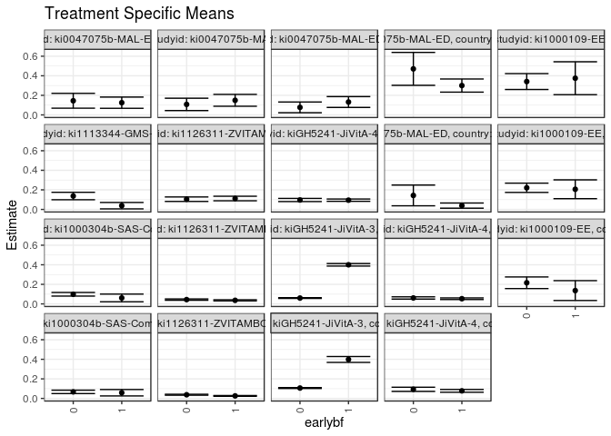

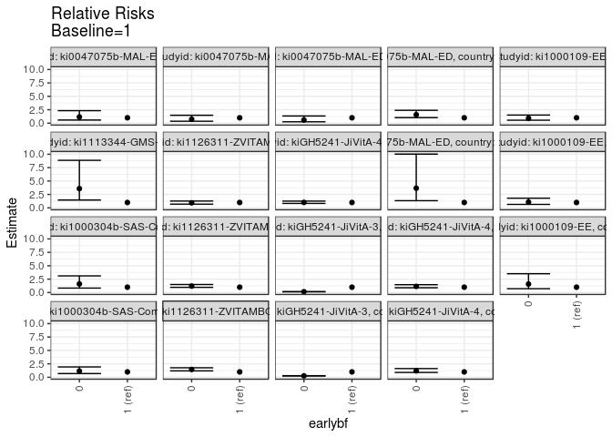

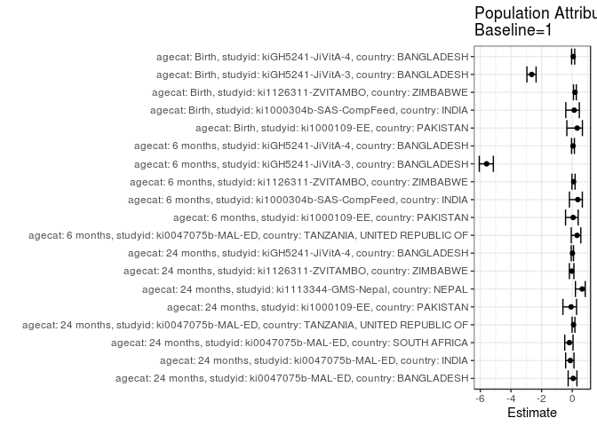

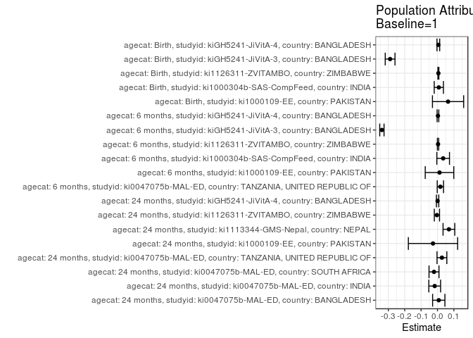

## Results Table

### Parameter: TSM

| agecat | studyid | country | intervention_level | baseline_level | estimate | ci_lower | ci_upper |
| --- | --- | --- | --- | --- | --- | --- | --- |
| Birth | ki1000109-EE | PAKISTAN | 1 | NA | 0.1363636 | 0.0347419 | 0.2379854 |
| Birth | ki1000109-EE | PAKISTAN | 0 | NA | 0.2162162 | 0.1567658 | 0.2756666 |
| Birth | ki1000304b-SAS-CompFeed | INDIA | 1 | NA | 0.0581395 | 0.0251640 | 0.0911151 |
| Birth | ki1000304b-SAS-CompFeed | INDIA | 0 | NA | 0.0669045 | 0.0492927 | 0.0845164 |
| Birth | ki1126311-ZVITAMBO | ZIMBABWE | 1 | NA | 0.0257779 | 0.0219417 | 0.0296141 |
| Birth | ki1126311-ZVITAMBO | ZIMBABWE | 0 | NA | 0.0374267 | 0.0325409 | 0.0423125 |
| Birth | kiGH5241-JiVitA-3 | BANGLADESH | 1 | NA | 0.3983051 | 0.3683122 | 0.4282979 |
| Birth | kiGH5241-JiVitA-3 | BANGLADESH | 0 | NA | 0.1060811 | 0.1014565 | 0.1107058 |
| Birth | kiGH5241-JiVitA-4 | BANGLADESH | 1 | NA | 0.0774059 | 0.0632529 | 0.0915588 |
| Birth | kiGH5241-JiVitA-4 | BANGLADESH | 0 | NA | 0.0933041 | 0.0720841 | 0.1145240 |
| 6 months | ki0047075b-MAL-ED | TANZANIA, UNITED REPUBLIC OF | 1 | NA | 0.0390244 | 0.0124614 | 0.0655873 |
| 6 months | ki0047075b-MAL-ED | TANZANIA, UNITED REPUBLIC OF | 0 | NA | 0.1428571 | 0.0368142 | 0.2489001 |
| 6 months | ki1000109-EE | PAKISTAN | 1 | NA | 0.2058824 | 0.1096444 | 0.3021203 |
| 6 months | ki1000109-EE | PAKISTAN | 0 | NA | 0.2210884 | 0.1735875 | 0.2685894 |
| 6 months | ki1000304b-SAS-CompFeed | INDIA | 1 | NA | 0.0612245 | 0.0218241 | 0.1006248 |
| 6 months | ki1000304b-SAS-CompFeed | INDIA | 0 | NA | 0.0985460 | 0.0798882 | 0.1172039 |
| 6 months | ki1126311-ZVITAMBO | ZIMBABWE | 1 | NA | 0.0366618 | 0.0309410 | 0.0423827 |
| 6 months | ki1126311-ZVITAMBO | ZIMBABWE | 0 | NA | 0.0442005 | 0.0374406 | 0.0509603 |
| 6 months | kiGH5241-JiVitA-3 | BANGLADESH | 1 | NA | 0.4000000 | 0.3872339 | 0.4127661 |
| 6 months | kiGH5241-JiVitA-3 | BANGLADESH | 0 | NA | 0.0599666 | 0.0560319 | 0.0639013 |
| 6 months | kiGH5241-JiVitA-4 | BANGLADESH | 1 | NA | 0.0533290 | 0.0449696 | 0.0616884 |
| 6 months | kiGH5241-JiVitA-4 | BANGLADESH | 0 | NA | 0.0610248 | 0.0494038 | 0.0726457 |
| 24 months | ki0047075b-MAL-ED | BANGLADESH | 1 | NA | 0.1250000 | 0.0675707 | 0.1824293 |
| 24 months | ki0047075b-MAL-ED | BANGLADESH | 0 | NA | 0.1445783 | 0.0687411 | 0.2204155 |
| 24 months | ki0047075b-MAL-ED | INDIA | 1 | NA | 0.1492537 | 0.0887869 | 0.2097205 |
| 24 months | ki0047075b-MAL-ED | INDIA | 0 | NA | 0.1075269 | 0.0444280 | 0.1706257 |
| 24 months | ki0047075b-MAL-ED | SOUTH AFRICA | 1 | NA | 0.1319444 | 0.0765505 | 0.1873384 |
| 24 months | ki0047075b-MAL-ED | SOUTH AFRICA | 0 | NA | 0.0769231 | 0.0220574 | 0.1317887 |
| 24 months | ki0047075b-MAL-ED | TANZANIA, UNITED REPUBLIC OF | 1 | NA | 0.3000000 | 0.2328975 | 0.3671025 |
| 24 months | ki0047075b-MAL-ED | TANZANIA, UNITED REPUBLIC OF | 0 | NA | 0.4705882 | 0.3024204 | 0.6387561 |
| 24 months | ki1000109-EE | PAKISTAN | 1 | NA | 0.3750000 | 0.2067493 | 0.5432507 |
| 24 months | ki1000109-EE | PAKISTAN | 0 | NA | 0.3409091 | 0.2597978 | 0.4220204 |
| 24 months | ki1113344-GMS-Nepal | NEPAL | 1 | NA | 0.0381679 | 0.0053206 | 0.0710153 |
| 24 months | ki1113344-GMS-Nepal | NEPAL | 0 | NA | 0.1369427 | 0.0988746 | 0.1750108 |
| 24 months | ki1126311-ZVITAMBO | ZIMBABWE | 1 | NA | 0.1115760 | 0.0885224 | 0.1346296 |
| 24 months | ki1126311-ZVITAMBO | ZIMBABWE | 0 | NA | 0.1044993 | 0.0816495 | 0.1273491 |
| 24 months | kiGH5241-JiVitA-4 | BANGLADESH | 1 | NA | 0.0946746 | 0.0828874 | 0.1064617 |
| 24 months | kiGH5241-JiVitA-4 | BANGLADESH | 0 | NA | 0.0964912 | 0.0803423 | 0.1126402 |

### Parameter: E(Y)

| agecat | studyid | country | intervention_level | baseline_level | estimate | ci_lower | ci_upper |
| --- | --- | --- | --- | --- | --- | --- | --- |
| Birth | ki1000109-EE | PAKISTAN | NA | NA | 0.2008734 | 0.1488678 | 0.2528789 |
| Birth | ki1000304b-SAS-CompFeed | INDIA | NA | NA | 0.0662800 | 0.0486880 | 0.0838721 |
| Birth | ki1126311-ZVITAMBO | ZIMBABWE | NA | NA | 0.0312449 | 0.0281769 | 0.0343130 |
| Birth | kiGH5241-JiVitA-3 | BANGLADESH | NA | NA | 0.1091641 | 0.1046058 | 0.1137223 |
| Birth | kiGH5241-JiVitA-4 | BANGLADESH | NA | NA | 0.0825363 | 0.0708486 | 0.0942240 |
| 6 months | ki0047075b-MAL-ED | TANZANIA, UNITED REPUBLIC OF | NA | NA | 0.0566802 | 0.0277850 | 0.0855754 |
| 6 months | ki1000109-EE | PAKISTAN | NA | NA | 0.2182320 | 0.1756239 | 0.2608402 |
| 6 months | ki1000304b-SAS-CompFeed | INDIA | NA | NA | 0.0958084 | 0.0774939 | 0.1141229 |
| 6 months | ki1126311-ZVITAMBO | ZIMBABWE | NA | NA | 0.0401403 | 0.0357552 | 0.0445254 |
| 6 months | kiGH5241-JiVitA-3 | BANGLADESH | NA | NA | 0.0606746 | 0.0568229 | 0.0645262 |
| 6 months | kiGH5241-JiVitA-4 | BANGLADESH | NA | NA | 0.0560960 | 0.0493335 | 0.0628586 |
| 24 months | ki0047075b-MAL-ED | BANGLADESH | NA | NA | 0.1327014 | 0.0868175 | 0.1785853 |
| 24 months | ki0047075b-MAL-ED | INDIA | NA | NA | 0.1321586 | 0.0880054 | 0.1763117 |
| 24 months | ki0047075b-MAL-ED | SOUTH AFRICA | NA | NA | 0.1106383 | 0.0704470 | 0.1508296 |
| 24 months | ki0047075b-MAL-ED | TANZANIA, UNITED REPUBLIC OF | NA | NA | 0.3271028 | 0.2640978 | 0.3901078 |
| 24 months | ki1000109-EE | PAKISTAN | NA | NA | 0.3475610 | 0.2744572 | 0.4206647 |
| 24 months | ki1113344-GMS-Nepal | NEPAL | NA | NA | 0.1078652 | 0.0790107 | 0.1367196 |
| 24 months | ki1126311-ZVITAMBO | ZIMBABWE | NA | NA | 0.1081081 | 0.0918715 | 0.1243447 |
| 24 months | kiGH5241-JiVitA-4 | BANGLADESH | NA | NA | 0.0953283 | 0.0857752 | 0.1048814 |

### Parameter: RR

| agecat | studyid | country | intervention_level | baseline_level | estimate | ci_lower | ci_upper |
| --- | --- | --- | --- | --- | --- | --- | --- |
| Birth | ki1000109-EE | PAKISTAN | 1 | 1 | 1.0000000 | 1.0000000 | 1.0000000 |
| Birth | ki1000109-EE | PAKISTAN | 0 | 1 | 1.5855856 | 0.7164987 | 3.5088434 |
| Birth | ki1000304b-SAS-CompFeed | INDIA | 1 | 1 | 1.0000000 | 1.0000000 | 1.0000000 |
| Birth | ki1000304b-SAS-CompFeed | INDIA | 0 | 1 | 1.1507583 | 0.6866757 | 1.9284861 |
| Birth | ki1126311-ZVITAMBO | ZIMBABWE | 1 | 1 | 1.0000000 | 1.0000000 | 1.0000000 |
| Birth | ki1126311-ZVITAMBO | ZIMBABWE | 0 | 1 | 1.4518902 | 1.1911357 | 1.7697270 |
| Birth | kiGH5241-JiVitA-3 | BANGLADESH | 1 | 1 | 1.0000000 | 1.0000000 | 1.0000000 |
| Birth | kiGH5241-JiVitA-3 | BANGLADESH | 0 | 1 | 0.2663314 | 0.2436377 | 0.2911389 |
| Birth | kiGH5241-JiVitA-4 | BANGLADESH | 1 | 1 | 1.0000000 | 1.0000000 | 1.0000000 |
| Birth | kiGH5241-JiVitA-4 | BANGLADESH | 0 | 1 | 1.2053876 | 0.8984987 | 1.6170966 |
| 6 months | ki0047075b-MAL-ED | TANZANIA, UNITED REPUBLIC OF | 1 | 1 | 1.0000000 | 1.0000000 | 1.0000000 |
| 6 months | ki0047075b-MAL-ED | TANZANIA, UNITED REPUBLIC OF | 0 | 1 | 3.6607143 | 1.3371210 | 10.0221514 |
| 6 months | ki1000109-EE | PAKISTAN | 1 | 1 | 1.0000000 | 1.0000000 | 1.0000000 |
| 6 months | ki1000109-EE | PAKISTAN | 0 | 1 | 1.0738581 | 0.6419818 | 1.7962679 |
| 6 months | ki1000304b-SAS-CompFeed | INDIA | 1 | 1 | 1.0000000 | 1.0000000 | 1.0000000 |
| 6 months | ki1000304b-SAS-CompFeed | INDIA | 0 | 1 | 1.6095854 | 0.8339140 | 3.1067532 |
| 6 months | ki1126311-ZVITAMBO | ZIMBABWE | 1 | 1 | 1.0000000 | 1.0000000 | 1.0000000 |
| 6 months | ki1126311-ZVITAMBO | ZIMBABWE | 0 | 1 | 1.2056254 | 0.9689971 | 1.5000382 |
| 6 months | kiGH5241-JiVitA-3 | BANGLADESH | 1 | 1 | 1.0000000 | 1.0000000 | 1.0000000 |
| 6 months | kiGH5241-JiVitA-3 | BANGLADESH | 0 | 1 | 0.1499165 | 0.1392160 | 0.1614396 |
| 6 months | kiGH5241-JiVitA-4 | BANGLADESH | 1 | 1 | 1.0000000 | 1.0000000 | 1.0000000 |
| 6 months | kiGH5241-JiVitA-4 | BANGLADESH | 0 | 1 | 1.1443066 | 0.8936321 | 1.4652984 |
| 24 months | ki0047075b-MAL-ED | BANGLADESH | 1 | 1 | 1.0000000 | 1.0000000 | 1.0000000 |
| 24 months | ki0047075b-MAL-ED | BANGLADESH | 0 | 1 | 1.1566265 | 0.5759183 | 2.3228725 |
| 24 months | ki0047075b-MAL-ED | INDIA | 1 | 1 | 1.0000000 | 1.0000000 | 1.0000000 |
| 24 months | ki0047075b-MAL-ED | INDIA | 0 | 1 | 0.7204301 | 0.3531055 | 1.4698710 |
| 24 months | ki0047075b-MAL-ED | SOUTH AFRICA | 1 | 1 | 1.0000000 | 1.0000000 | 1.0000000 |
| 24 months | ki0047075b-MAL-ED | SOUTH AFRICA | 0 | 1 | 0.5829960 | 0.2548159 | 1.3338424 |
| 24 months | ki0047075b-MAL-ED | TANZANIA, UNITED REPUBLIC OF | 1 | 1 | 1.0000000 | 1.0000000 | 1.0000000 |
| 24 months | ki0047075b-MAL-ED | TANZANIA, UNITED REPUBLIC OF | 0 | 1 | 1.5686275 | 1.0290289 | 2.3911788 |
| 24 months | ki1000109-EE | PAKISTAN | 1 | 1 | 1.0000000 | 1.0000000 | 1.0000000 |
| 24 months | ki1000109-EE | PAKISTAN | 0 | 1 | 0.9090909 | 0.5470796 | 1.5106509 |
| 24 months | ki1113344-GMS-Nepal | NEPAL | 1 | 1 | 1.0000000 | 1.0000000 | 1.0000000 |
| 24 months | ki1113344-GMS-Nepal | NEPAL | 0 | 1 | 3.5878971 | 1.4523513 | 8.8635618 |
| 24 months | ki1126311-ZVITAMBO | ZIMBABWE | 1 | 1 | 1.0000000 | 1.0000000 | 1.0000000 |
| 24 months | ki1126311-ZVITAMBO | ZIMBABWE | 0 | 1 | 0.9365748 | 0.6932509 | 1.2653027 |
| 24 months | kiGH5241-JiVitA-4 | BANGLADESH | 1 | 1 | 1.0000000 | 1.0000000 | 1.0000000 |
| 24 months | kiGH5241-JiVitA-4 | BANGLADESH | 0 | 1 | 1.0191886 | 0.8278169 | 1.2548009 |

### Parameter: PAR

| agecat | studyid | country | intervention_level | baseline_level | estimate | ci_lower | ci_upper |
| --- | --- | --- | --- | --- | --- | --- | --- |
| Birth | ki1000109-EE | PAKISTAN | 1 | NA | 0.0645097 | -0.0306907 | 0.1597101 |
| Birth | ki1000304b-SAS-CompFeed | INDIA | 1 | NA | 0.0081405 | -0.0199419 | 0.0362229 |
| Birth | ki1126311-ZVITAMBO | ZIMBABWE | 1 | NA | 0.0054670 | 0.0025499 | 0.0083842 |
| Birth | kiGH5241-JiVitA-3 | BANGLADESH | 1 | NA | -0.2891410 | -0.3189717 | -0.2593104 |
| Birth | kiGH5241-JiVitA-4 | BANGLADESH | 1 | NA | 0.0051305 | -0.0031643 | 0.0134252 |
| 6 months | ki0047075b-MAL-ED | TANZANIA, UNITED REPUBLIC OF | 1 | NA | 0.0176558 | -0.0015614 | 0.0368729 |
| 6 months | ki1000109-EE | PAKISTAN | 1 | NA | 0.0123497 | -0.0748148 | 0.0995142 |
| 6 months | ki1000304b-SAS-CompFeed | INDIA | 1 | NA | 0.0345839 | -0.0039983 | 0.0731661 |
| 6 months | ki1126311-ZVITAMBO | ZIMBABWE | 1 | NA | 0.0034785 | -0.0006086 | 0.0075655 |
| 6 months | kiGH5241-JiVitA-3 | BANGLADESH | 1 | NA | -0.3393254 | -0.3524760 | -0.3261749 |
| 6 months | kiGH5241-JiVitA-4 | BANGLADESH | 1 | NA | 0.0027670 | -0.0023767 | 0.0079107 |
| 24 months | ki0047075b-MAL-ED | BANGLADESH | 1 | NA | 0.0077014 | -0.0297411 | 0.0451439 |
| 24 months | ki0047075b-MAL-ED | INDIA | 1 | NA | -0.0170951 | -0.0529995 | 0.0188092 |
| 24 months | ki0047075b-MAL-ED | SOUTH AFRICA | 1 | NA | -0.0213061 | -0.0516920 | 0.0090797 |
| 24 months | ki0047075b-MAL-ED | TANZANIA, UNITED REPUBLIC OF | 1 | NA | 0.0271028 | -0.0028582 | 0.0570638 |
| 24 months | ki1000109-EE | PAKISTAN | 1 | NA | -0.0274390 | -0.1777897 | 0.1229116 |
| 24 months | ki1113344-GMS-Nepal | NEPAL | 1 | NA | 0.0696972 | 0.0339722 | 0.1054223 |
| 24 months | ki1126311-ZVITAMBO | ZIMBABWE | 1 | NA | -0.0034679 | -0.0193752 | 0.0124394 |
| 24 months | kiGH5241-JiVitA-4 | BANGLADESH | 1 | NA | 0.0006537 | -0.0065193 | 0.0078268 |

### Parameter: PAF

| agecat | studyid | country | intervention_level | baseline_level | estimate | ci_lower | ci_upper |
| --- | --- | --- | --- | --- | --- | --- | --- |
| Birth | ki1000109-EE | PAKISTAN | 1 | NA | 0.3211462 | -0.3548268 | 0.6598514 |
| Birth | ki1000304b-SAS-CompFeed | INDIA | 1 | NA | 0.1228198 | -0.4233308 | 0.4594052 |
| Birth | ki1126311-ZVITAMBO | ZIMBABWE | 1 | NA | 0.1749732 | 0.0778093 | 0.2618998 |
| Birth | kiGH5241-JiVitA-3 | BANGLADESH | 1 | NA | -2.6486833 | -2.9602145 | -2.3616588 |
| Birth | kiGH5241-JiVitA-4 | BANGLADESH | 1 | NA | 0.0621599 | -0.0440919 | 0.1575990 |
| 6 months | ki0047075b-MAL-ED | TANZANIA, UNITED REPUBLIC OF | 1 | NA | 0.3114983 | -0.0691645 | 0.5566308 |
| 6 months | ki1000109-EE | PAKISTAN | 1 | NA | 0.0565897 | -0.4405711 | 0.3821735 |
| 6 months | ki1000304b-SAS-CompFeed | INDIA | 1 | NA | 0.3609694 | -0.1862100 | 0.6557438 |
| 6 months | ki1126311-ZVITAMBO | ZIMBABWE | 1 | NA | 0.0866574 | -0.0205986 | 0.1826417 |
| 6 months | kiGH5241-JiVitA-3 | BANGLADESH | 1 | NA | -5.5925490 | -6.0679100 | -5.1491590 |
| 6 months | kiGH5241-JiVitA-4 | BANGLADESH | 1 | NA | 0.0493265 | -0.0469310 | 0.1367339 |
| 24 months | ki0047075b-MAL-ED | BANGLADESH | 1 | NA | 0.0580357 | -0.2702485 | 0.3014779 |
| 24 months | ki0047075b-MAL-ED | INDIA | 1 | NA | -0.1293532 | -0.4336153 | 0.1103340 |
| 24 months | ki0047075b-MAL-ED | SOUTH AFRICA | 1 | NA | -0.1925748 | -0.4934545 | 0.0476880 |
| 24 months | ki0047075b-MAL-ED | TANZANIA, UNITED REPUBLIC OF | 1 | NA | 0.0828571 | -0.0133013 | 0.1698905 |
| 24 months | ki1000109-EE | PAKISTAN | 1 | NA | -0.0789474 | -0.6111773 | 0.2774678 |
| 24 months | ki1113344-GMS-Nepal | NEPAL | 1 | NA | 0.6461513 | 0.2037010 | 0.8427615 |
| 24 months | ki1126311-ZVITAMBO | ZIMBABWE | 1 | NA | -0.0320781 | -0.1901585 | 0.1050056 |
| 24 months | kiGH5241-JiVitA-4 | BANGLADESH | 1 | NA | 0.0068576 | -0.0712951 | 0.0793090 |